# Risk Factor Analysis

## Outcome Variable

**Outcome Variable:** haz

## Predictor Variables

**Intervention Variable:** trth2o

**Adjustment Set:**

- arm
- sex
- W_mage
- meducyrs
- feducyrs
- hhwealth_quart
- hfoodsec
- W_mhtcm
- W_mwtkg
- W_mbmi
- W_nrooms
- W_nhh
- W_nchldlt5
- brthmon
- cleanck
- impfloor
- impsan
- safeh20
- delta_meducyrs
- delta_feducyrs
- delta_hhwealth_quart
- delta_hfoodsec
- delta_W_mhtcm
- delta_W_mwtkg
- delta_W_mbmi
- delta_W_nrooms
- delta_W_nhh
- delta_W_nchldlt5
- delta_brthmon
- delta_cleanck
- delta_impfloor
- delta_impsan
- delta_safeh20

## Stratifying Variables

The analysis was stratified on these variable(s):

- agecat
- studyid
- country

## Data Summary

| agecat | studyid | country | trth2o | n_cell | n | outcome_variable |
| --- | --- | --- | --- | --- | --- | --- |
| Birth | CMC-V-BCS-2002 | INDIA | 1 | 26 | 26 | haz |
| Birth | CMC-V-BCS-2002 | INDIA | 0 | 0 | 26 | haz |
| Birth | GMS-Nepal | NEPAL | 1 | 1 | 4 | haz |
| Birth | GMS-Nepal | NEPAL | 0 | 3 | 4 | haz |
| Birth | IRC | INDIA | 1 | 120 | 120 | haz |
| Birth | IRC | INDIA | 0 | 0 | 120 | haz |
| Birth | MAL-ED | BANGLADESH | 1 | 117 | 119 | haz |
| Birth | MAL-ED | BANGLADESH | 0 | 2 | 119 | haz |
| Birth | MAL-ED | BRAZIL | 1 | 4 | 22 | haz |
| Birth | MAL-ED | BRAZIL | 0 | 18 | 22 | haz |
| Birth | MAL-ED | INDIA | 1 | 0 | 2 | haz |
| Birth | MAL-ED | INDIA | 0 | 2 | 2 | haz |
| Birth | MAL-ED | NEPAL | 1 | 7 | 9 | haz |
| Birth | MAL-ED | NEPAL | 0 | 2 | 9 | haz |
| Birth | MAL-ED | PERU | 1 | 28 | 36 | haz |
| Birth | MAL-ED | PERU | 0 | 8 | 36 | haz |
| Birth | MAL-ED | SOUTH AFRICA | 1 | 1 | 5 | haz |
| Birth | MAL-ED | SOUTH AFRICA | 0 | 4 | 5 | haz |
| Birth | MAL-ED | TANZANIA, UNITED REPUBLIC OF | 1 | 4 | 22 | haz |
| Birth | MAL-ED | TANZANIA, UNITED REPUBLIC OF | 0 | 18 | 22 | haz |
| Birth | NIH-Crypto | BANGLADESH | 1 | 409 | 732 | haz |
| Birth | NIH-Crypto | BANGLADESH | 0 | 323 | 732 | haz |
| Birth | PROVIDE | BANGLADESH | 1 | 12 | 539 | haz |
| Birth | PROVIDE | BANGLADESH | 0 | 527 | 539 | haz |
| 6 months | CMC-V-BCS-2002 | INDIA | 1 | 120 | 120 | haz |
| 6 months | CMC-V-BCS-2002 | INDIA | 0 | 0 | 120 | haz |
| 6 months | GMS-Nepal | NEPAL | 1 | 1 | 4 | haz |
| 6 months | GMS-Nepal | NEPAL | 0 | 3 | 4 | haz |
| 6 months | IRC | INDIA | 1 | 121 | 121 | haz |
| 6 months | IRC | INDIA | 0 | 0 | 121 | haz |
| 6 months | MAL-ED | BANGLADESH | 1 | 132 | 134 | haz |
| 6 months | MAL-ED | BANGLADESH | 0 | 2 | 134 | haz |
| 6 months | MAL-ED | BRAZIL | 1 | 13 | 103 | haz |
| 6 months | MAL-ED | BRAZIL | 0 | 90 | 103 | haz |
| 6 months | MAL-ED | INDIA | 1 | 4 | 9 | haz |
| 6 months | MAL-ED | INDIA | 0 | 5 | 9 | haz |
| 6 months | MAL-ED | NEPAL | 1 | 69 | 83 | haz |
| 6 months | MAL-ED | NEPAL | 0 | 14 | 83 | haz |
| 6 months | MAL-ED | PERU | 1 | 39 | 49 | haz |
| 6 months | MAL-ED | PERU | 0 | 10 | 49 | haz |
| 6 months | MAL-ED | SOUTH AFRICA | 1 | 2 | 12 | haz |
| 6 months | MAL-ED | SOUTH AFRICA | 0 | 10 | 12 | haz |
| 6 months | MAL-ED | TANZANIA, UNITED REPUBLIC OF | 1 | 6 | 42 | haz |
| 6 months | MAL-ED | TANZANIA, UNITED REPUBLIC OF | 0 | 36 | 42 | haz |
| 6 months | NIH-Crypto | BANGLADESH | 1 | 396 | 715 | haz |
| 6 months | NIH-Crypto | BANGLADESH | 0 | 319 | 715 | haz |
| 6 months | PROVIDE | BANGLADESH | 1 | 14 | 604 | haz |
| 6 months | PROVIDE | BANGLADESH | 0 | 590 | 604 | haz |
| 24 months | CMC-V-BCS-2002 | INDIA | 1 | 119 | 119 | haz |
| 24 months | CMC-V-BCS-2002 | INDIA | 0 | 0 | 119 | haz |
| 24 months | GMS-Nepal | NEPAL | 1 | 1 | 4 | haz |
| 24 months | GMS-Nepal | NEPAL | 0 | 3 | 4 | haz |
| 24 months | IRC | INDIA | 1 | 121 | 121 | haz |
| 24 months | IRC | INDIA | 0 | 0 | 121 | haz |
| 24 months | MAL-ED | BANGLADESH | 1 | 133 | 135 | haz |
| 24 months | MAL-ED | BANGLADESH | 0 | 2 | 135 | haz |
| 24 months | MAL-ED | BRAZIL | 1 | 13 | 103 | haz |
| 24 months | MAL-ED | BRAZIL | 0 | 90 | 103 | haz |
| 24 months | MAL-ED | INDIA | 1 | 4 | 9 | haz |
| 24 months | MAL-ED | INDIA | 0 | 5 | 9 | haz |
| 24 months | MAL-ED | NEPAL | 1 | 69 | 83 | haz |
| 24 months | MAL-ED | NEPAL | 0 | 14 | 83 | haz |
| 24 months | MAL-ED | PERU | 1 | 39 | 49 | haz |
| 24 months | MAL-ED | PERU | 0 | 10 | 49 | haz |
| 24 months | MAL-ED | SOUTH AFRICA | 1 | 2 | 11 | haz |
| 24 months | MAL-ED | SOUTH AFRICA | 0 | 9 | 11 | haz |
| 24 months | MAL-ED | TANZANIA, UNITED REPUBLIC OF | 1 | 6 | 43 | haz |
| 24 months | MAL-ED | TANZANIA, UNITED REPUBLIC OF | 0 | 37 | 43 | haz |
| 24 months | NIH-Crypto | BANGLADESH | 1 | 242 | 514 | haz |
| 24 months | NIH-Crypto | BANGLADESH | 0 | 272 | 514 | haz |
| 24 months | PROVIDE | BANGLADESH | 1 | 14 | 578 | haz |
| 24 months | PROVIDE | BANGLADESH | 0 | 564 | 578 | haz |

The following strata were considered:

- agecat: 24 months, studyid: CMC-V-BCS-2002, country: INDIA
- agecat: 24 months, studyid: GMS-Nepal, country: NEPAL
- agecat: 24 months, studyid: IRC, country: INDIA
- agecat: 24 months, studyid: MAL-ED, country: BANGLADESH
- agecat: 24 months, studyid: MAL-ED, country: BRAZIL
- agecat: 24 months, studyid: MAL-ED, country: INDIA
- agecat: 24 months, studyid: MAL-ED, country: NEPAL
- agecat: 24 months, studyid: MAL-ED, country: PERU
- agecat: 24 months, studyid: MAL-ED, country: SOUTH AFRICA
- agecat: 24 months, studyid: MAL-ED, country: TANZANIA, UNITED REPUBLIC OF
- agecat: 24 months, studyid: NIH-Crypto, country: BANGLADESH
- agecat: 24 months, studyid: PROVIDE, country: BANGLADESH
- agecat: 6 months, studyid: CMC-V-BCS-2002, country: INDIA
- agecat: 6 months, studyid: GMS-Nepal, country: NEPAL
- agecat: 6 months, studyid: IRC, country: INDIA
- agecat: 6 months, studyid: MAL-ED, country: BANGLADESH
- agecat: 6 months, studyid: MAL-ED, country: BRAZIL
- agecat: 6 months, studyid: MAL-ED, country: INDIA
- agecat: 6 months, studyid: MAL-ED, country: NEPAL
- agecat: 6 months, studyid: MAL-ED, country: PERU
- agecat: 6 months, studyid: MAL-ED, country: SOUTH AFRICA
- agecat: 6 months, studyid: MAL-ED, country: TANZANIA, UNITED REPUBLIC OF
- agecat: 6 months, studyid: NIH-Crypto, country: BANGLADESH
- agecat: 6 months, studyid: PROVIDE, country: BANGLADESH
- agecat: Birth, studyid: CMC-V-BCS-2002, country: INDIA
- agecat: Birth, studyid: GMS-Nepal, country: NEPAL
- agecat: Birth, studyid: IRC, country: INDIA
- agecat: Birth, studyid: MAL-ED, country: BANGLADESH
- agecat: Birth, studyid: MAL-ED, country: BRAZIL
- agecat: Birth, studyid: MAL-ED, country: INDIA
- agecat: Birth, studyid: MAL-ED, country: NEPAL
- agecat: Birth, studyid: MAL-ED, country: PERU
- agecat: Birth, studyid: MAL-ED, country: SOUTH AFRICA
- agecat: Birth, studyid: MAL-ED, country: TANZANIA, UNITED REPUBLIC OF
- agecat: Birth, studyid: NIH-Crypto, country: BANGLADESH
- agecat: Birth, studyid: PROVIDE, country: BANGLADESH

### Dropped Strata

Some strata were dropped due to rare outcomes:

- agecat: Birth, studyid: CMC-V-BCS-2002, country: INDIA
- agecat: Birth, studyid: GMS-Nepal, country: NEPAL
- agecat: Birth, studyid: IRC, country: INDIA
- agecat: Birth, studyid: MAL-ED, country: BANGLADESH
- agecat: Birth, studyid: MAL-ED, country: BRAZIL
- agecat: Birth, studyid: MAL-ED, country: INDIA
- agecat: Birth, studyid: MAL-ED, country: NEPAL
- agecat: Birth, studyid: MAL-ED, country: SOUTH AFRICA
- agecat: Birth, studyid: MAL-ED, country: TANZANIA, UNITED REPUBLIC OF
- agecat: 6 months, studyid: CMC-V-BCS-2002, country: INDIA
- agecat: 6 months, studyid: GMS-Nepal, country: NEPAL
- agecat: 6 months, studyid: IRC, country: INDIA
- agecat: 6 months, studyid: MAL-ED, country: BANGLADESH
- agecat: 6 months, studyid: MAL-ED, country: INDIA
- agecat: 6 months, studyid: MAL-ED, country: SOUTH AFRICA
- agecat: 24 months, studyid: CMC-V-BCS-2002, country: INDIA
- agecat: 24 months, studyid: GMS-Nepal, country: NEPAL
- agecat: 24 months, studyid: IRC, country: INDIA
- agecat: 24 months, studyid: MAL-ED, country: BANGLADESH
- agecat: 24 months, studyid: MAL-ED, country: INDIA
- agecat: 24 months, studyid: MAL-ED, country: SOUTH AFRICA

## Methods Detail

We’re interested in the causal parameters $E[Y_a]$ for all values of $a \in \mathcal{A}$. These parameters represent the mean outcome if, possibly contrary to fact, we intervened to set all units to have $A=a$. Under the randomization and positivity assumptions, these are identified by the statistical parameters $\psi_a=E_W[E_{Y|A,W}(Y|A=a,W)]$. In addition, we’re interested in the mean of $Y$, $E[Y]$ under no intervention (the observed mean). We will estimate these parameters by using SuperLearner to fit the relevant likelihood factors – $E_{Y|A,W}(Y|A=a,W)$ and $p(A=a|W)$, and then updating our likelihood fit using a joint TMLE.

For unadjusted analyses ($W=\{\}$), initial likelihoods were estimated using Lrnr_glm to estimate the simple $E(Y|A)$ and Lrnr_mean to estimate $p(A)$. For adjusted analyses, a small library containing Lrnr_glmnet, Lrnr_xgboost, and Lrnr_mean was used.

Having estimated these parameters, we will then use the delta method to estimate relative risks and attributable risks relative to a prespecified baseline level of $A$.

# Results Detail

## Results Plots

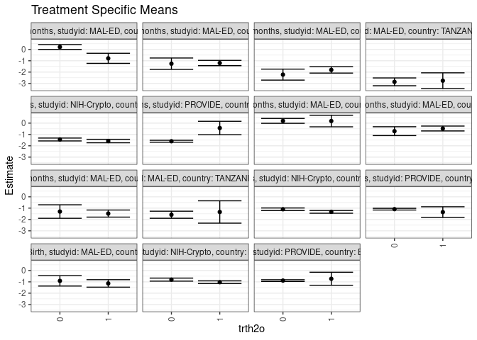

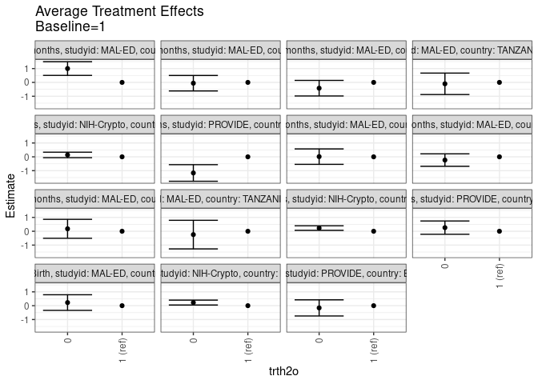

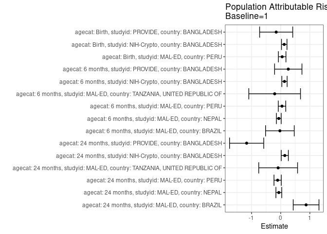

## Results Table

### Parameter: TSM

| agecat | studyid | country | intervention_level | baseline_level | estimate | ci_lower | ci_upper |
| --- | --- | --- | --- | --- | --- | --- | --- |
| Birth | MAL-ED | PERU | 1 | NA | -1.1403571 | -1.4705172 | -0.8101971 |
| Birth | MAL-ED | PERU | 0 | NA | -0.9150000 | -1.3733730 | -0.4566270 |
| Birth | NIH-Crypto | BANGLADESH | 1 | NA | -1.0301776 | -1.1468777 | -0.9134775 |
| Birth | NIH-Crypto | BANGLADESH | 0 | NA | -0.8044554 | -0.9384931 | -0.6704176 |
| Birth | PROVIDE | BANGLADESH | 1 | NA | -0.7297669 | -1.3062229 | -0.1533108 |
| Birth | PROVIDE | BANGLADESH | 0 | NA | -0.8895380 | -0.9650700 | -0.8140061 |
| 6 months | MAL-ED | BRAZIL | 1 | NA | 0.1838961 | -0.3279052 | 0.6956974 |
| 6 months | MAL-ED | BRAZIL | 0 | NA | 0.1977999 | -0.0169853 | 0.4125851 |
| 6 months | MAL-ED | NEPAL | 1 | NA | -0.4764954 | -0.6922454 | -0.2607454 |
| 6 months | MAL-ED | NEPAL | 0 | NA | -0.7111675 | -1.1017093 | -0.3206257 |
| 6 months | MAL-ED | PERU | 1 | NA | -1.4786466 | -1.7900995 | -1.1671938 |
| 6 months | MAL-ED | PERU | 0 | NA | -1.3007482 | -1.8954453 | -0.7060511 |
| 6 months | MAL-ED | TANZANIA, UNITED REPUBLIC OF | 1 | NA | -1.3394444 | -2.3247416 | -0.3541473 |
| 6 months | MAL-ED | TANZANIA, UNITED REPUBLIC OF | 0 | NA | -1.5815278 | -1.8930135 | -1.2700421 |
| 6 months | NIH-Crypto | BANGLADESH | 1 | NA | -1.3280984 | -1.4488486 | -1.2073482 |
| 6 months | NIH-Crypto | BANGLADESH | 0 | NA | -1.0972775 | -1.2097465 | -0.9848084 |
| 6 months | PROVIDE | BANGLADESH | 1 | NA | -1.3513065 | -1.8248177 | -0.8777953 |
| 6 months | PROVIDE | BANGLADESH | 0 | NA | -1.0898244 | -1.1654600 | -1.0141889 |
| 24 months | MAL-ED | BRAZIL | 1 | NA | -0.7874078 | -1.2316891 | -0.3431264 |
| 24 months | MAL-ED | BRAZIL | 0 | NA | 0.2123305 | -0.0028147 | 0.4274756 |
| 24 months | MAL-ED | NEPAL | 1 | NA | -1.2019708 | -1.4357825 | -0.9681591 |
| 24 months | MAL-ED | NEPAL | 0 | NA | -1.2608335 | -1.7632998 | -0.7583671 |
| 24 months | MAL-ED | PERU | 1 | NA | -1.8042841 | -2.0867760 | -1.5217922 |
| 24 months | MAL-ED | PERU | 0 | NA | -2.2233275 | -2.7087583 | -1.7378968 |
| 24 months | MAL-ED | TANZANIA, UNITED REPUBLIC OF | 1 | NA | -2.7600000 | -3.4536768 | -2.0663232 |
| 24 months | MAL-ED | TANZANIA, UNITED REPUBLIC OF | 0 | NA | -2.8620270 | -3.2058314 | -2.5182226 |
| 24 months | NIH-Crypto | BANGLADESH | 1 | NA | -1.5813426 | -1.7340211 | -1.4286640 |
| 24 months | NIH-Crypto | BANGLADESH | 0 | NA | -1.4446094 | -1.5715340 | -1.3176849 |
| 24 months | PROVIDE | BANGLADESH | 1 | NA | -0.4336871 | -1.0262676 | 0.1588934 |
| 24 months | PROVIDE | BANGLADESH | 0 | NA | -1.5990299 | -1.6833641 | -1.5146956 |

### Parameter: E(Y)

| agecat | studyid | country | intervention_level | baseline_level | estimate | ci_lower | ci_upper |
| --- | --- | --- | --- | --- | --- | --- | --- |
| Birth | MAL-ED | PERU | NA | NA | -1.0902778 | -1.3682718 | -0.8122837 |
| Birth | NIH-Crypto | BANGLADESH | NA | NA | -0.9094945 | -0.9809370 | -0.8380521 |
| Birth | PROVIDE | BANGLADESH | NA | NA | -0.8851020 | -0.9601332 | -0.8100709 |
| 6 months | MAL-ED | BRAZIL | NA | NA | 0.1558900 | -0.0436128 | 0.3553927 |
| 6 months | MAL-ED | NEPAL | NA | NA | -0.5416867 | -0.7337282 | -0.3496452 |
| 6 months | MAL-ED | PERU | NA | NA | -1.4335034 | -1.6988926 | -1.1681142 |
| 6 months | MAL-ED | TANZANIA, UNITED REPUBLIC OF | NA | NA | -1.5469444 | -1.8498756 | -1.2440133 |
| 6 months | NIH-Crypto | BANGLADESH | NA | NA | -1.1986783 | -1.2700937 | -1.1272630 |
| 6 months | PROVIDE | BANGLADESH | NA | NA | -1.0916915 | -1.1661176 | -1.0172654 |
| 24 months | MAL-ED | BRAZIL | NA | NA | 0.0833172 | -0.1220854 | 0.2887197 |
| 24 months | MAL-ED | NEPAL | NA | NA | -1.2665060 | -1.4788044 | -1.0542077 |
| 24 months | MAL-ED | PERU | NA | NA | -1.9093878 | -2.1570845 | -1.6616910 |
| 24 months | MAL-ED | TANZANIA, UNITED REPUBLIC OF | NA | NA | -2.8477907 | -3.1592380 | -2.5363434 |
| 24 months | NIH-Crypto | BANGLADESH | NA | NA | -1.4412646 | -1.5249156 | -1.3576135 |
| 24 months | PROVIDE | BANGLADESH | NA | NA | -1.6024221 | -1.6857420 | -1.5191023 |

### Parameter: ATE

| agecat | studyid | country | intervention_level | baseline_level | estimate | ci_lower | ci_upper |
| --- | --- | --- | --- | --- | --- | --- | --- |
| Birth | MAL-ED | PERU | 1 | 1 | 0.0000000 | 0.0000000 | 0.0000000 |
| Birth | MAL-ED | PERU | 0 | 1 | 0.2253571 | -0.3395424 | 0.7902567 |
| Birth | NIH-Crypto | BANGLADESH | 1 | 1 | 0.0000000 | 0.0000000 | 0.0000000 |
| Birth | NIH-Crypto | BANGLADESH | 0 | 1 | 0.2257223 | 0.0486210 | 0.4028235 |
| Birth | PROVIDE | BANGLADESH | 1 | 1 | 0.0000000 | 0.0000000 | 0.0000000 |
| Birth | PROVIDE | BANGLADESH | 0 | 1 | -0.1597712 | -0.7420774 | 0.4225351 |
| 6 months | MAL-ED | BRAZIL | 1 | 1 | 0.0000000 | 0.0000000 | 0.0000000 |
| 6 months | MAL-ED | BRAZIL | 0 | 1 | 0.0139038 | -0.5443652 | 0.5721728 |
| 6 months | MAL-ED | NEPAL | 1 | 1 | 0.0000000 | 0.0000000 | 0.0000000 |
| 6 months | MAL-ED | NEPAL | 0 | 1 | -0.2346721 | -0.6836130 | 0.2142688 |
| 6 months | MAL-ED | PERU | 1 | 1 | 0.0000000 | 0.0000000 | 0.0000000 |
| 6 months | MAL-ED | PERU | 0 | 1 | 0.1778984 | -0.5053467 | 0.8611435 |
| 6 months | MAL-ED | TANZANIA, UNITED REPUBLIC OF | 1 | 1 | 0.0000000 | 0.0000000 | 0.0000000 |
| 6 months | MAL-ED | TANZANIA, UNITED REPUBLIC OF | 0 | 1 | -0.2420833 | -1.2754438 | 0.7912771 |
| 6 months | NIH-Crypto | BANGLADESH | 1 | 1 | 0.0000000 | 0.0000000 | 0.0000000 |
| 6 months | NIH-Crypto | BANGLADESH | 0 | 1 | 0.2308209 | 0.0656255 | 0.3960163 |
| 6 months | PROVIDE | BANGLADESH | 1 | 1 | 0.0000000 | 0.0000000 | 0.0000000 |
| 6 months | PROVIDE | BANGLADESH | 0 | 1 | 0.2614820 | -0.2178874 | 0.7408515 |
| 24 months | MAL-ED | BRAZIL | 1 | 1 | 0.0000000 | 0.0000000 | 0.0000000 |
| 24 months | MAL-ED | BRAZIL | 0 | 1 | 0.9997382 | 0.5051691 | 1.4943074 |
| 24 months | MAL-ED | NEPAL | 1 | 1 | 0.0000000 | 0.0000000 | 0.0000000 |
| 24 months | MAL-ED | NEPAL | 0 | 1 | -0.0588627 | -0.6172823 | 0.4995569 |
| 24 months | MAL-ED | PERU | 1 | 1 | 0.0000000 | 0.0000000 | 0.0000000 |
| 24 months | MAL-ED | PERU | 0 | 1 | -0.4190434 | -0.9811419 | 0.1430550 |
| 24 months | MAL-ED | TANZANIA, UNITED REPUBLIC OF | 1 | 1 | 0.0000000 | 0.0000000 | 0.0000000 |
| 24 months | MAL-ED | TANZANIA, UNITED REPUBLIC OF | 0 | 1 | -0.1020270 | -0.8762292 | 0.6721752 |
| 24 months | NIH-Crypto | BANGLADESH | 1 | 1 | 0.0000000 | 0.0000000 | 0.0000000 |
| 24 months | NIH-Crypto | BANGLADESH | 0 | 1 | 0.1367331 | -0.0621366 | 0.3356028 |
| 24 months | PROVIDE | BANGLADESH | 1 | 1 | 0.0000000 | 0.0000000 | 0.0000000 |
| 24 months | PROVIDE | BANGLADESH | 0 | 1 | -1.1653428 | -1.7647031 | -0.5659825 |

### Parameter: PAR

| agecat | studyid | country | intervention_level | baseline_level | estimate | ci_lower | ci_upper |
| --- | --- | --- | --- | --- | --- | --- | --- |
| Birth | MAL-ED | PERU | 1 | NA | 0.0500794 | -0.0792342 | 0.1793930 |
| Birth | NIH-Crypto | BANGLADESH | 1 | NA | 0.1206831 | 0.0269421 | 0.2144241 |
| Birth | PROVIDE | BANGLADESH | 1 | NA | -0.1553352 | -0.7231931 | 0.4125227 |
| 6 months | MAL-ED | BRAZIL | 1 | NA | -0.0280061 | -0.5196294 | 0.4636171 |
| 6 months | MAL-ED | NEPAL | 1 | NA | -0.0651914 | -0.1471977 | 0.0168150 |
| 6 months | MAL-ED | PERU | 1 | NA | 0.0451432 | -0.0832576 | 0.1735441 |
| 6 months | MAL-ED | TANZANIA, UNITED REPUBLIC OF | 1 | NA | -0.2075000 | -1.0936170 | 0.6786170 |
| 6 months | NIH-Crypto | BANGLADESH | 1 | NA | 0.1294201 | 0.0384790 | 0.2203612 |
| 6 months | PROVIDE | BANGLADESH | 1 | NA | 0.2596150 | -0.2095208 | 0.7287508 |
| 24 months | MAL-ED | BRAZIL | 1 | NA | 0.8707249 | 0.4287563 | 1.3126936 |
| 24 months | MAL-ED | NEPAL | 1 | NA | -0.0645352 | -0.1645061 | 0.0354356 |
| 24 months | MAL-ED | PERU | 1 | NA | -0.1051036 | -0.2302230 | 0.0200158 |
| 24 months | MAL-ED | TANZANIA, UNITED REPUBLIC OF | 1 | NA | -0.0877907 | -0.7540505 | 0.5784691 |
| 24 months | NIH-Crypto | BANGLADESH | 1 | NA | 0.1400780 | 0.0180660 | 0.2620900 |
| 24 months | PROVIDE | BANGLADESH | 1 | NA | -1.1687351 | -1.7551151 | -0.5823550 |